# Geological Resources

Dr. Ahmad Redaa

2025-05-03

# Outlines

- Mineral Resources
- Energy Resources
- Introduction to Economic Geology
- Formation of Ore Deposits
- Formation of Oil and Gas

# Mineral Resources

- **Metallic Minerals**
  - *Examples:* Gold, Silver, Copper, Iron.
- **Non-Metallic Minerals**
  - *Examples:* Phosphate, Barite, Gypsum.
- **Building Materials**
  - *Examples:* Sand, Gravel, Limestone, Granite.

# Energy Resources

- **Renewable Energy Resources**
  - *Examples:* Solar, Wind, Hydropower, Biomass.
- **Non-Renewable Energy Resources**
  - *Examples:* Coal, Oil, Natural Gas, Uranium.

# Economic Geology

**Economic geology** is the branch of geology that deals with earth materials of economic value, focusing on the origin, discovery, extraction, and use of mineral and energy resources.

# Terms in Economic Geology

| **Term** | **Definition** |
| --- | --- |
| **Ore** | Rock or material that contains sufficient quantities of valuable minerals or metals that can be extracted profitably. |
| **Deposit** | A naturally occurring concentration of minerals or hydrocarbons that is economically viable to extract. |
| **Porphyry** | A large, disseminated mineral deposit formed from hydrothermal fluids associated with a cooling intrusive body, typically rich in copper, molybdenum, and sometimes gold. |
| **Vein** | A sheet-like body of crystallized minerals within a rock, often formed from hydrothermal fluids and frequently hosting ore minerals. |
| **Ore mineral** | A mineral that contains a metal or valuable element that can be economically extracted (e.g., chalcopyrite for copper, galena for lead). |
| **Gangue mineral** | The non-valuable minerals found within an ore deposit that are discarded during ore processing (e.g., quartz, feldspar). |
| **Reservoir** | A porous and permeable geological formation that stores and transmits oil or gas; usually overlain by an impermeable cap rock that traps the hydrocarbons. |
| **Source rock** | A sedimentary rock rich in organic material that, under heat and pressure, generates and releases oil or gas into adjacent reservoir rocks. |
| **Trap** | A geological structure that impedes the upward movement of hydrocarbons, allowing them to accumulate in a reservoir; examples include anticlines, faults, and salt domes. |
| **Cap rock** | An impermeable rock layer, such as shale or salt, that overlies a reservoir rock and prevents the escape of hydrocarbons. |
| **Migration** | The movement of hydrocarbons from a source rock into a reservoir rock through porous rocks or fractures. |

# Formation of Mineral Resources

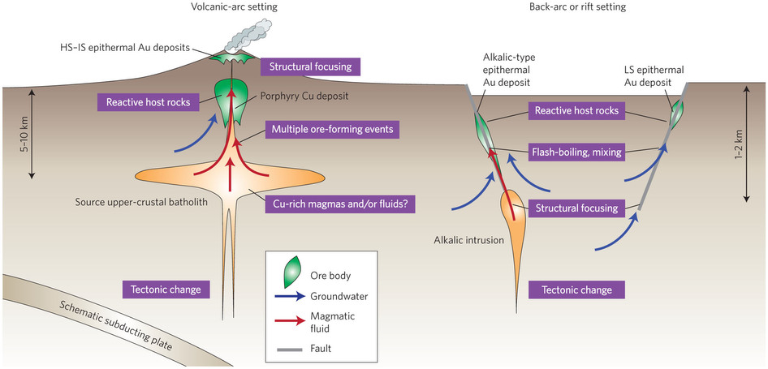

Source: [https://www.geologyin.com](https://www.geologyin.com/2015/11/how-ore-deposits-are-formed.html)

- Mineral deposits form through several geological processes that concentrate elements into economically valuable quantities.
  - Magmatic Processes
  - Hydrothermal Processes
  - Sedimentary Processes
  - Metamorphic Processes
  - Supergene Enrichment

# Magmatic Processes

- **Definition**: Crystallization of minerals from **cooling magma**.
- **Mechanism**: Dense minerals settle out early from mafic magmas.
- **Common Deposits**:
  - **Chromite**
  - **Magnetite**
  - **Platinum-group elements (PGEs)**

# Hydrothermal Processes

- **Definition**: Deposition of minerals from **hot, metal-rich fluids**.
- **Mechanism**: Fluids move through fractures, depositing minerals as temperature or chemistry changes.
- **Examples**:
  - **Porphyry copper deposits**
  - **Gold-quartz veins**
  - **Lead-zinc veins**

# Sedimentary Processes

- **Definition**: Metal concentration via **chemical or physical sedimentation**.
- **Mechanisms**:
  - **Chemical precipitation** in marine basins
  - **Mechanical concentration** in rivers
- **Examples**:
  - **Banded Iron Formations (BIFs)**
  - **Placer deposits** (e.g., gold, tin, diamonds)

# Metamorphic Processes

- **Definition**: Re-distribution of metals during **metamorphism**.
- **Mechanism**: Heat and pressure mobilize fluids that enrich certain zones.
- **Examples**:
  - **Shear zone-hosted gold**
  - **Graphite deposits**

# Supergene Enrichment

- **Definition**: **Weathering** near the surface leads to metal enrichment at depth.
- **Mechanism**: Leaching removes metals from the upper zone and reprecipitates them below.
- **Examples**:
  - **Enriched copper zones** below oxide caps
  - **Silver enrichment in epithermal systems**

# Metallic Minerals

**Metallic minerals** are naturally occurring substances that contain **metal elements** in sufficient quantities to make extraction economically viable. These minerals are typically found in **igneous**, **metamorphic**, or **sedimentary rocks**, and are mined for the **metals** they contain.

## Key Characteristics of Metallic Minerals

- Have **metallic luster** (they look shiny or reflective).
- Are generally **dense** and **conduct electricity** and **heat** well.
- Can be **melted** to extract the metal.
- Often occur in **veins**, **lodes**, or **disseminated deposits**.

## Examples of Metallic Minerals

| **Mineral** | **Metal Extracted** |
| --- | --- |
| **Chalcopyrite** | Copper (Cu) |
| **Galena** | Lead (Pb) |
| **Hematite** | Iron (Fe) |
| **Bauxite** | Aluminum (Al) |
| **Sphalerite** | Zinc (Zn) |
| **Wolframite** | Tungsten (W) |
| **Ilmenite** | Titanium (Ti) |
| **Gold/Silver** | Precious metals (Au, Ag) |

# Non-Metallic Minerals

**Non-metallic minerals** are naturally occurring minerals that **do not contain metals** or do not yield metallic products when processed. These minerals are used **in their natural form** or after minimal processing, often in **construction, agriculture, and industrial applications**.

## Key Characteristics of Non-Metallic Minerals

- Do not have metallic luster (often dull or earthy).
- Are usually **insulators** (do not conduct heat or electricity).
- Do not produce metals when melted or processed.
- Are typically found in **sedimentary** or **metamorphic rocks**.

## Examples of Non-Metallic Minerals

| **Mineral** | **Use/Application** |
| --- | --- |
| **Halite (NaCl)** | Table salt, chemical industry |
| **Gypsum** | Plaster, drywall, fertilizer |
| **Phosphate** | Fertilizers |
| **Barite** | Drilling mud in oil and gas industry |
| **Anhydrite** | Cement, soil treatment |
| **Sulfur** | Sulfuric acid production, fertilizers |
| **Quartz** | Glass, electronics, construction |
| **Clay** | Ceramics, bricks, paper filler |

# Building Materials

- **Building materials** are naturally occurring rocks and minerals (or products derived from them) that are **used in construction and civil engineering projects**.
- They form the foundation of **infrastructure, housing, roads, and public works**.

## Key Characteristics of Building Materials

- Typically **abundant and locally available**.
- Selected for their **strength**, **durability**, and **resistance** to weathering.
- Can be used in **natural form** (e.g., stone) or **processed** (e.g., cement).

### Examples of Common Building Materials

| **Material** | **Use/Application** |
| --- | --- |
| **Sand** | Concrete, mortar, glass production |
| **Gravel** | Concrete aggregate, road base |
| **Limestone** | Cement, construction stone, lime production |
| **Granite** | Dimensional stone, countertops, cladding |
| **Clay** | Bricks, tiles, ceramics |
| **Slate** | Roofing, flooring, wall panels |
| **Gypsum** | Drywall, plaster, interior finishing |

# Renewable Energy Resources

- **Definition**: Energy sources that are **naturally replenished** on a human timescale.
- **Characteristics**: Sustainable, low emissions, eco-friendly.
- **Examples**:
  - **Solar** – Photovoltaic panels
  - **Wind** – Wind turbines
  - **Hydropower** – Dams and rivers
  - **Biomass** – Organic material
  - **Geothermal** – Earth’s internal heat

# Geothermal Energy

- Geothermal energy is heat derived from within the Earth. It can be used directly for heating or to generate electricity.

## **Sources of Geothermal Energy**

- Originates from the Earth’s internal heat:
  - **Residual heat** from planet formation.
  - **Radioactive decay** of elements like uranium and thorium.
- Heat is concentrated in areas with **recent volcanic activity**, **hot springs**, or **tectonic plate boundaries**.

## **Geological Settings Favorable for Geothermal**

- **Volcanic regions** (e.g., Iceland, Pacific Ring of Fire).

## **Uses and Importance**

- Electricity generation through **steam turbines**.
- Direct heating for **buildings, greenhouses, and aquaculture**.
- Considered a **renewable and sustainable** energy source with low emissions.

# Non-Renewable Energy Resources

- **Definition**: Finite energy sources formed over **millions of years**.
- **Concerns**: Non-sustainable, cause pollution and climate change.
- **Examples**:
  - **Coal** – Electricity, steel
  - **Oil** – Transportation fuels
  - **Natural Gas** – Heating and power
  - **Uranium** – Nuclear energy

# Formation of Oil and Gas

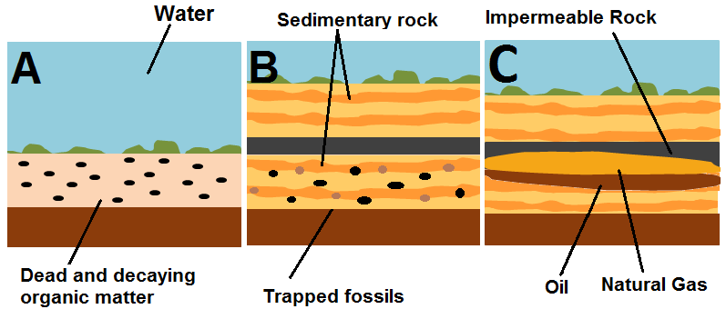

Source: [https://energyeducation.ca](https://energyeducation.ca/encyclopedia/Oil_formation)

The formation of oil and gas involves a series of biological, chemical, and geological processes over millions of years.

## 1. Organic Matter Accumulation

- Originates from **marine microorganisms** like plankton.
- Their remains settle on the **sea floor**.
- In **low-oxygen environments**, organic matter is preserved in fine-grained **muddy sediments**.

## 2. Burial and Source Rock Formation

- Sediments bury the organic-rich layers.
- **Temperature and pressure** increase with depth.
- **Organic-rich shales** become **source rocks**.

## 3. Thermal Maturation

- **60–120°C**: Oil forms in the **oil window**.
- **>120°C**: Gas forms as residual matter converts.
- Heat causes transformation into **liquid and gaseous hydrocarbons**.

## 4. Migration

- Oil and gas **migrate upward** due to lower density.
- Move from **source rock** into **porous reservoir rocks** like sandstone or limestone.

## 5. Trapping

- Movement stops when fluids reach a **trap**.
- **Cap rocks** (e.g., shale, salt) seal the reservoir.
- Types of traps:
  - **Anticline**
  - **Fault trap**
  - **Stratigraphic trap**
  - **Salt dome**

## 6. Reservoir Accumulation

- Fluids accumulate and segregate by density:
  - **Gas** on top
  - **Oil** in the middle
  - **Water** at the bottom